# Facteurs de risque et de protection de la naissance prématurée : une analyse par régression logistique

Stella Ganmene

2025

## Contexte

Ce travail applique la régression logistique à un jeu de données sur les naissances prématurées, dans le but d’identifier les facteurs de risque et les facteurs protecteurs associés à cet événement, et d’évaluer la qualité prédictive du modèle obtenu.

## Packages nécessaires

```r
# install.packages("ROCR")
# install.packages("gtsummary")
library(ROCR)
library(gtsummary)
```

## Chargement et exploration des données

```r
load("prema.RData")
head(prema)
```

```
##   GEST DILATE EFFACE CONSIS CONTR MEMBRAN AGE STRAT GRAVID PARIT DIAB TRANSF
## 1   31      3    100  Ferme   Oui     Non  26     3      1     0  Non    Non
## 2   28      8      0  Ferme   Oui     Non  25     3      1     0  Non    Oui
## 3   31      3    100  Ferme   Non     Non  28     3      2     0  Non    Oui
## 4   27      2     75  Ferme   Non     Non  27     2      2     1  Non    Oui
## 5   28      6     75  Ferme   Non     Non  17     3      1     0  Non    Oui
## 6   33      2    100  Ferme   Oui     Oui  25     4      2     0  Non    Oui
##      GEMEL PREMATURE
## 1   Simple   positif
## 2 Multiple   positif
## 3   Simple   positif
## 4 Multiple   positif
## 5   Simple   positif
## 6   Simple   positif
```

Vérification du type des variables :

```r
str(prema)
```

```
## 'data.frame':    388 obs. of  14 variables:
##  $ GEST     : int  31 28 31 27 28 33 32 30 33 28 ...
##  $ DILATE   : int  3 8 3 2 6 2 4 1 0 0 ...
##  $ EFFACE   : int  100 0 100 75 75 100 75 50 25 0 ...
##  $ CONSIS   : Factor w/ 3 levels "Mou","Moyen",..: 3 3 3 3 3 3 3 3 3 1 ...
##  $ CONTR    : Factor w/ 2 levels "Oui","Non": 1 1 2 2 2 1 1 1 1 1 ...
##  $ MEMBRAN  : Factor w/ 3 levels "Oui","Non","Incertain": 2 2 2 2 2 1 2 2 2 2 ...
##  $ AGE      : int  26 25 28 27 17 25 25 29 22 25 ...
##  $ STRAT    : Factor w/ 4 levels "1","2","3","4": 3 3 3 2 3 4 4 3 4 3 ...
##  $ GRAVID   : int  1 1 2 2 1 2 2 2 1 3 ...
##  $ PARIT    : int  0 0 0 1 0 0 1 1 0 1 ...
##  $ DIAB     : Factor w/ 2 levels "Oui","Non": 2 2 2 2 2 2 2 2 2 2 ...
##  $ TRANSF   : Factor w/ 2 levels "Oui","Non": 2 1 1 1 1 1 1 1 2 2 ...
##  $ GEMEL    : Factor w/ 2 levels "Simple","Multiple": 1 2 1 2 1 1 1 1 2 1 ...
##  $ PREMATURE: Factor w/ 2 levels "negatif","positif": 2 2 2 2 2 2 2 2 1 2 ...
```

### Exploration des variables quantitatives

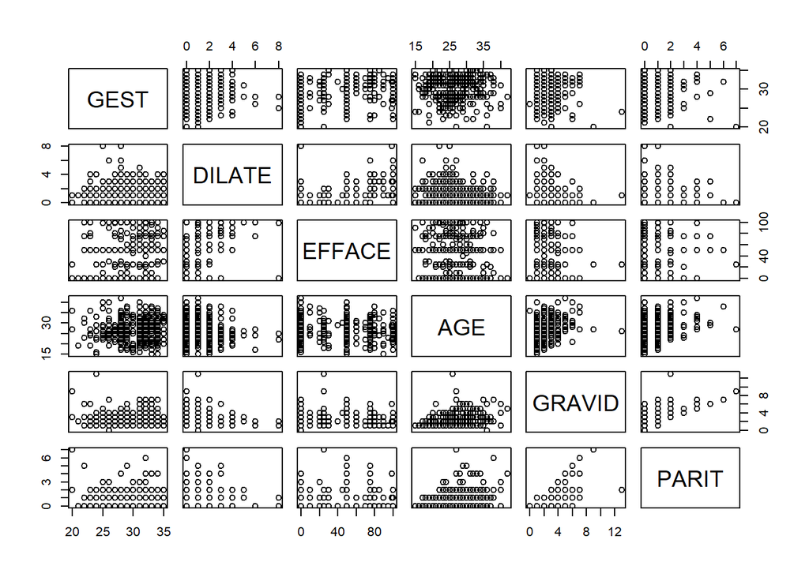

```r
var_quant <- prema[, sapply(prema, is.numeric)]
pairs(prema[, c(1, 2, 3, 7, 9, 10)])
```

La variable de gestité (nombre de grossesses) semble liée linéairement à la parité (nombre de grossesses à terme) : l’une augmente lorsque l’autre augmente.

```r
cor(prema[, c(1, 2, 3, 7, 9, 10)])
```

```
##               GEST      DILATE      EFFACE         AGE      GRAVID       PARIT
## GEST    1.00000000 -0.04392068  0.10590864  0.04395977 -0.14377692 -0.11346924
## DILATE -0.04392068  1.00000000  0.52995178 -0.07434610 -0.07125411 -0.03208094
## EFFACE  0.10590864  0.52995178  1.00000000 -0.04164738 -0.08727401 -0.14536500
## AGE     0.04395977 -0.07434610 -0.04164738  1.00000000  0.29910799  0.31450402
## GRAVID -0.14377692 -0.07125411 -0.08727401  0.29910799  1.00000000  0.71957093
## PARIT  -0.11346924 -0.03208094 -0.14536500  0.31450402  0.71957093  1.00000000
```

On observe une forte corrélation positive entre parité et gestité, ainsi qu’une corrélation positive entre effacement et dilatation du col.

### Exploration des variables qualitatives

```r
var_cat <- prema[, sapply(prema, is.factor)]
```

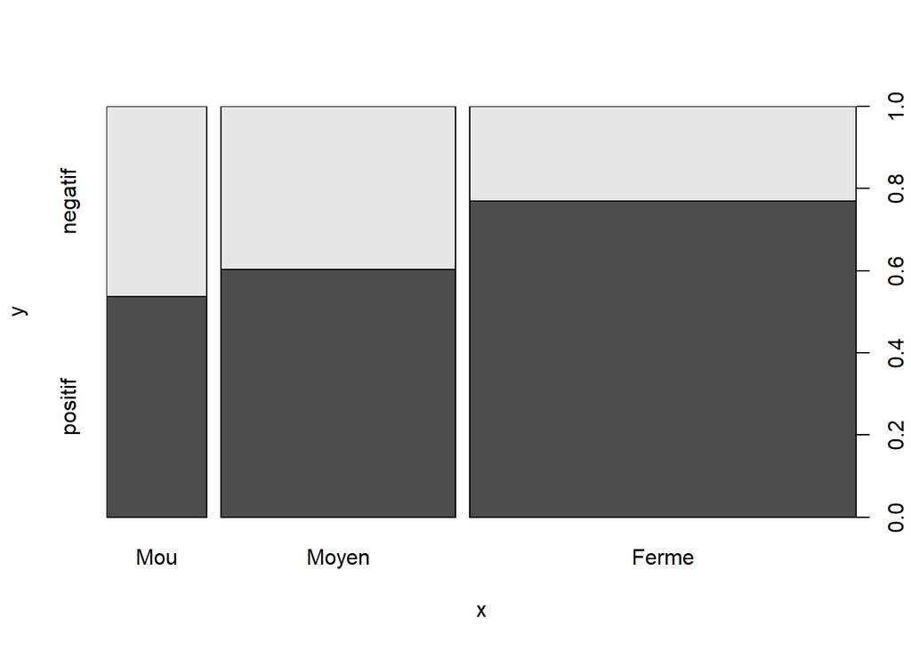

```r
plot(prema$CONSIS, prema$PREMATURE)
```

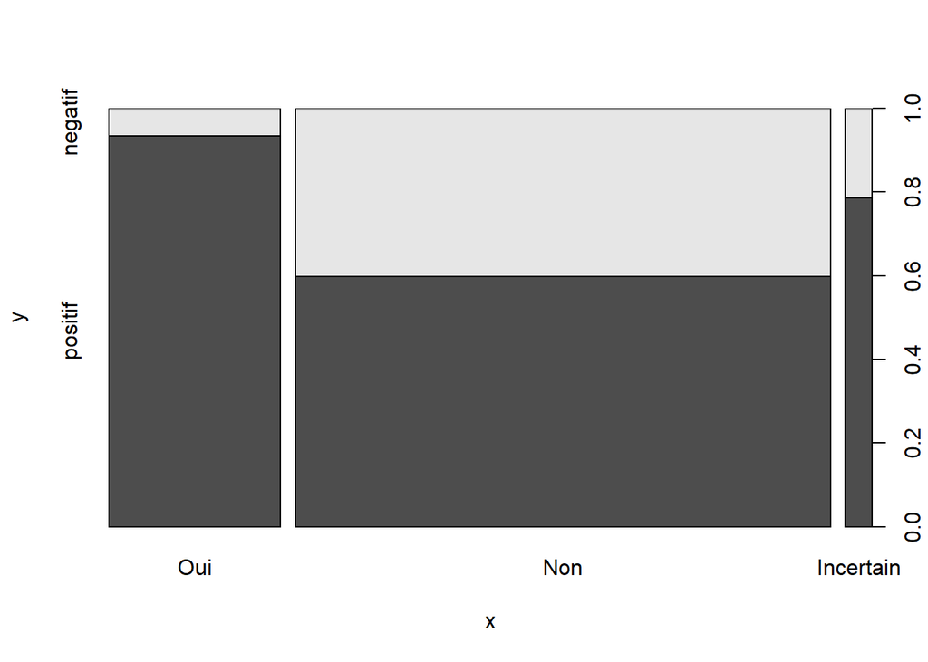

```r
plot(prema$MEMBRAN, prema$PREMATURE)
```

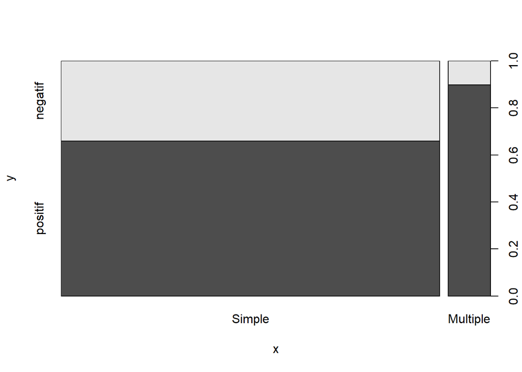

```r
plot(prema$GEMEL, prema$PREMATURE)
```

### Analyse bidimensionnelle

```r
tbl_summary(prema, by = PREMATURE) %>% add_p()
```

[output not shown]

| **Characteristic** | **negatif** N = 123<sup>1</sup> | **positif** N = 265<sup>1</sup> | **p-value** |
| --- | --- | --- | --- |
| GEST | 32 (29, 33) | 31 (28, 33) |  |
| DILATE |  |  |  |
| 0 | 61 (50%) | 71 (27%) |  |
| 1 | 44 (36%) | 79 (30%) |  |
| 2 | 15 (12%) | 64 (24%) |  |
| 3 | 3 (2.4%) | 29 (11%) |  |
| 4 | 0 (0%) | 14 (5.3%) |  |
| 5 | 0 (0%) | 3 (1.1%) |  |
| 6 | 0 (0%) | 3 (1.1%) |  |
| 8 | 0 (0%) | 2 (0.8%) |  |
| EFFACE | 25 (0, 50) | 50 (20, 80) |  |
| CONSIS |  |  |  |
| Mou | 25 (20%) | 29 (11%) |  |
| Moyen | 50 (41%) | 76 (29%) |  |
| Ferme | 48 (39%) | 160 (60%) |  |
| CONTR |  |  |  |
| Oui | 117 (95%) | 238 (90%) |  |
| Non | 6 (4.9%) | 27 (10%) |  |
| MEMBRAN |  |  |  |
| Oui | 6 (4.9%) | 85 (32%) |  |
| Non | 114 (93%) | 169 (64%) |  |
| Incertain | 3 (2.4%) | 11 (4.2%) |  |
| AGE | 28 (23, 30) | 26 (23, 29) |  |
| STRAT |  |  |  |
| 1 | 3 (2.4%) | 11 (4.2%) |  |
| 2 | 12 (9.8%) | 40 (15%) |  |
| 3 | 46 (37%) | 107 (40%) |  |
| 4 | 62 (50%) | 107 (40%) |  |
| GRAVID | 2 (1, 3) | 2 (1, 3) |  |
| PARIT |  |  |  |
| 0 | 44 (36%) | 141 (53%) |  |
| 1 | 50 (41%) | 88 (33%) |  |
| 2 | 21 (17%) | 27 (10%) |  |
| 3 | 2 (1.6%) | 4 (1.5%) |  |
| 4 | 4 (3.3%) | 3 (1.1%) |  |
| 5 | 0 (0%) | 2 (0.8%) |  |
| 6 | 1 (0.8%) | 0 (0%) |  |
| 7 | 1 (0.8%) | 0 (0%) |  |
| DIAB |  |  |  |
| Oui | 2 (1.6%) | 9 (3.4%) |  |
| Non | 120 (98%) | 254 (97%) |  |
| Unknown | 1 | 2 |  |
| TRANSF |  |  |  |
| Oui | 38 (31%) | 149 (56%) |  |
| Non | 85 (69%) | 116 (44%) |  |
| GEMEL |  |  |  |
| Simple | 119 (97%) | 230 (87%) |  |
| Multiple | 4 (3.3%) | 35 (13%) |  |

<sup>1</sup> Median (Q1, Q3); n (%)

## Modélisation

### Modèle complet (Modèle 1)

```r
model1 <- glm(PREMATURE ~ ., family = "binomial", data = prema)
summary(model1)
```

```
##
## Call:
## glm(formula = PREMATURE ~ ., family = "binomial", data = prema)
##
## Coefficients:
##                   Estimate Std. Error z value Pr(>|z|)
## (Intercept)       4.179413   3.154945   1.325  0.18526
## GEST              0.031486   0.126861   0.248  0.80399
## DILATE            0.465620   0.160258   2.905  0.00367 **
## EFFACE            0.016293   0.004993   3.263  0.00110 **
## CONSISMoyen      -0.003735   0.413391  -0.009  0.99279
## CONSISFerme       0.109046   0.422942   0.258  0.79654
## CONTRNon         -0.271793   0.571600  -0.475  0.63443
## MEMBRANNon       -2.502556   0.504874  -4.957 7.17e-07 ***
## MEMBRANIncertain -1.743328   0.873314  -1.996  0.04591 *
## AGE              -0.024745   0.026793  -0.924  0.35571
## STRAT2           -0.513793   1.009553  -0.509  0.61080
## STRAT3           -1.027735   1.282474  -0.801  0.42292
## STRAT4           -1.651263   1.638381  -1.008  0.31352
## GRAVID            0.261498   0.147723   1.770  0.07670 .
## PARIT            -0.693088   0.206282  -3.360  0.00078 ***
## DIABNon          -1.381361   0.939525  -1.470  0.14149
## TRANSFNon        -0.500855   0.293511  -1.706  0.08793 .
## GEMELMultiple     1.182608   0.621102   1.904  0.05690 .
## ---
## Signif. codes:  0 '***' 0.001 '**' 0.01 '*' 0.05 '.' 0.1 ' ' 1
##
## (Dispersion parameter for binomial family taken to be 1)
##
##     Null deviance: 480.86  on 384  degrees of freedom
## Residual deviance: 349.28  on 367  degrees of freedom
##   (3 observations effacées parce que manquantes)
## AIC: 385.28
##
## Number of Fisher Scoring iterations: 6
```

Les variables significatives dans ce premier modèle sont la dilatation et l’effacement du col (état du col), l’état de la membrane, ainsi que la parité.

### Sélection automatique des variables (Modèle 2)

```r
model2 <- step(model1)
```

```
## Start:  AIC=385.28
## PREMATURE ~ GEST + DILATE + EFFACE + CONSIS + CONTR + MEMBRAN +
##     AGE + STRAT + GRAVID + PARIT + DIAB + TRANSF + GEMEL
##
##           Df Deviance    AIC
## - STRAT    3   350.78 380.78
## - CONSIS   2   349.43 381.43
## - GEST     1   349.35 383.35
## - CONTR    1   349.51 383.51
## - AGE      1   350.14 384.14
## <none>         349.28 385.28
## - DIAB     1   351.72 385.72
## - TRANSF   1   352.21 386.21
## - GRAVID   1   352.69 386.69
## - GEMEL    1   353.45 387.45
## - DILATE   1   358.69 392.69
## - EFFACE   1   360.45 394.45
## - PARIT    1   361.52 395.52
## - MEMBRAN  2   386.22 418.22
##
## Step:  AIC=380.78
## PREMATURE ~ GEST + DILATE + EFFACE + CONSIS + CONTR + MEMBRAN +
##     AGE + GRAVID + PARIT + DIAB + TRANSF + GEMEL
##
##           Df Deviance    AIC
## - CONSIS   2   350.98 376.98
## - CONTR    1   350.98 378.98
## - AGE      1   351.61 379.61
## <none>         350.78 380.78
## - DIAB     1   353.50 381.50
## - TRANSF   1   353.61 381.61
## - GRAVID   1   354.10 382.10
## - GEMEL    1   354.68 382.68
## - GEST     1   356.58 384.58
## - DILATE   1   360.87 388.87
## - EFFACE   1   361.52 389.52
## - PARIT    1   363.32 391.32
## - MEMBRAN  2   387.55 413.55
##
## Step:  AIC=376.98
```

[output cut: 34 more lines]

```
## Step:  AIC=374.04
## PREMATURE ~ GEST + DILATE + EFFACE + MEMBRAN + GRAVID + PARIT +
##     DIAB + TRANSF + GEMEL
##
##           Df Deviance    AIC
## <none>         352.04 374.04
## - DIAB     1   354.68 374.68
## - GRAVID   1   354.88 374.88
## - TRANSF   1   355.69 375.69
## - GEMEL    1   356.00 376.00
## - GEST     1   357.99 377.99
## - DILATE   1   362.95 382.95
## - EFFACE   1   364.42 384.42
## - PARIT    1   365.58 385.58
## - MEMBRAN  2   388.21 406.21
```

```r
summary(model2)
```

```
##
## Call:
## glm(formula = PREMATURE ~ GEST + DILATE + EFFACE + MEMBRAN +
##     GRAVID + PARIT + DIAB + TRANSF + GEMEL, family = "binomial",
##     data = prema)
##
## Coefficients:
##                   Estimate Std. Error z value Pr(>|z|)
## (Intercept)       6.553388   1.763494   3.716 0.000202 ***
## GEST             -0.105517   0.044198  -2.387 0.016969 *
## DILATE            0.492030   0.157614   3.122 0.001798 **
## EFFACE            0.016205   0.004724   3.430 0.000603 ***
## MEMBRANNon       -2.398824   0.490694  -4.889 1.02e-06 ***
## MEMBRANIncertain -1.613752   0.848176  -1.903 0.057091 .
## GRAVID            0.232827   0.143284   1.625 0.104177
## PARIT            -0.713576   0.202996  -3.515 0.000439 ***
## DIABNon          -1.424097   0.929195  -1.533 0.125371
## TRANSFNon        -0.535413   0.280747  -1.907 0.056508 .
## GEMELMultiple     1.138976   0.614374   1.854 0.063756 .
## ---
## Signif. codes:  0 '***' 0.001 '**' 0.01 '*' 0.05 '.' 0.1 ' ' 1
##
## (Dispersion parameter for binomial family taken to be 1)
##
##     Null deviance: 480.86  on 384  degrees of freedom
## Residual deviance: 352.04  on 374  degrees of freedom
##   (3 observations effacées parce que manquantes)
## AIC: 374.04
##
## Number of Fisher Scoring iterations: 5
```

Le modèle réduit conserve les variables les plus explicatives du risque d’accouchement prématuré identifiées dans le Modèle 1.

## Interprétation : facteurs de risque et facteurs protecteurs

```r
exp(cbind(OR = coef(model2), confint(model2)))
```

```
## Attente de la réalisation du profilage...
```

```
##                            OR       2.5 %       97.5 %
## (Intercept)      701.61700002 24.75278879 2.577511e+04
## GEST               0.89985930  0.82345028 9.797992e-01
## DILATE             1.63563388  1.21306873 2.251895e+00
## EFFACE             1.01633713  1.00712218 1.026003e+00
## MEMBRANNon         0.09082473  0.03135032 2.202332e-01
## MEMBRANIncertain   0.19913895  0.03851807 1.169389e+00
## GRAVID             1.26216300  0.96404506 1.692509e+00
## PARIT              0.48988898  0.32474761 7.215547e-01
## DIABNon            0.24072586  0.03012571 1.324061e+00
## TRANSFNon          0.58542751  0.33637329 1.013921e+00
## GEMELMultiple      3.12356957  1.01618286 1.191616e+01
```

```r
tbl_regression(model2, exponentiate = TRUE)
```

| **Characteristic** | **OR** | **95% CI** | **p-value** |
| --- | --- | --- | --- |
| GEST | 0.90 | 0.82, 0.98 | 0.017 |
| DILATE | 1.64 | 1.21, 2.25 | 0.002 |
| EFFACE | 1.02 | 1.01, 1.03 | <0.001 |
| MEMBRAN |  |  |  |
| Oui | — | — |  |
| Non | 0.09 | 0.03, 0.22 | <0.001 |
| Incertain | 0.20 | 0.04, 1.17 | 0.057 |
| GRAVID | 1.26 | 0.96, 1.69 | 0.10 |
| PARIT | 0.49 | 0.32, 0.72 | <0.001 |
| DIAB |  |  |  |
| Oui | — | — |  |
| Non | 0.24 | 0.03, 1.32 | 0.13 |
| TRANSF |  |  |  |
| Oui | — | — |  |
| Non | 0.59 | 0.34, 1.01 | 0.057 |
| GEMEL |  |  |  |
| Simple | — | — |  |
| Multiple | 3.12 | 1.02, 11.9 | 0.064 |

Abbreviations: CI = Confidence Interval, OR = Odds Ratio

**Facteurs de risque associés à l’accouchement prématuré :**

- Dilatation du col plus importante
- Nombre de grossesses antérieures (gestité) plus élevé
- Grossesse multiple

## Qualité prédictive du modèle

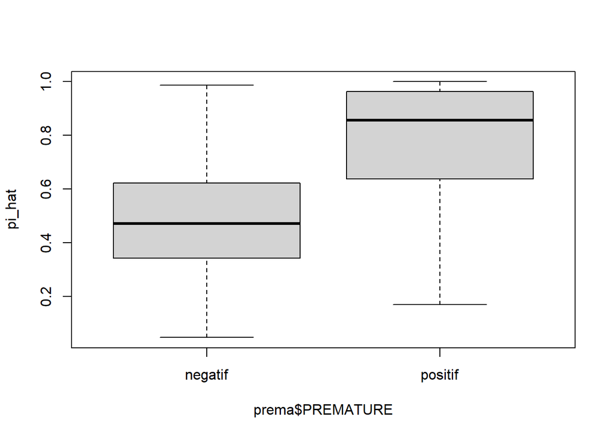

```r
pi_hat <- predict(model2, prema, type = "response")
boxplot(pi_hat ~ prema$PREMATURE)
```

Le modèle attribue des probabilités prédites nettement plus élevées aux cas réellement prématurés qu’aux cas non prématurés, ce qui traduit un bon pouvoir discriminant.

### Matrice de confusion (seuil = 0,5)

```r
y_hat <- as.factor(ifelse(pi_hat > 0.5, "predit pos", "predit neg"))
MatConf <- table(prema$PREMATURE, y_hat)
MatConf
```

```
##          y_hat
##           predit neg predit pos
##   negatif         66         56
##   positif         43        220
```

```r
prop.table(MatConf, margin = 1)
```

```
##          y_hat
##           predit neg predit pos
##   negatif  0.5409836  0.4590164
##   positif  0.1634981  0.8365019
```

Le modèle prédit correctement 83 % des accouchements prématurés (sensibilité) et 54 % des accouchements non prématurés (spécificité) : il est plus performant pour détecter les cas positifs que les cas négatifs.

### Courbe ROC

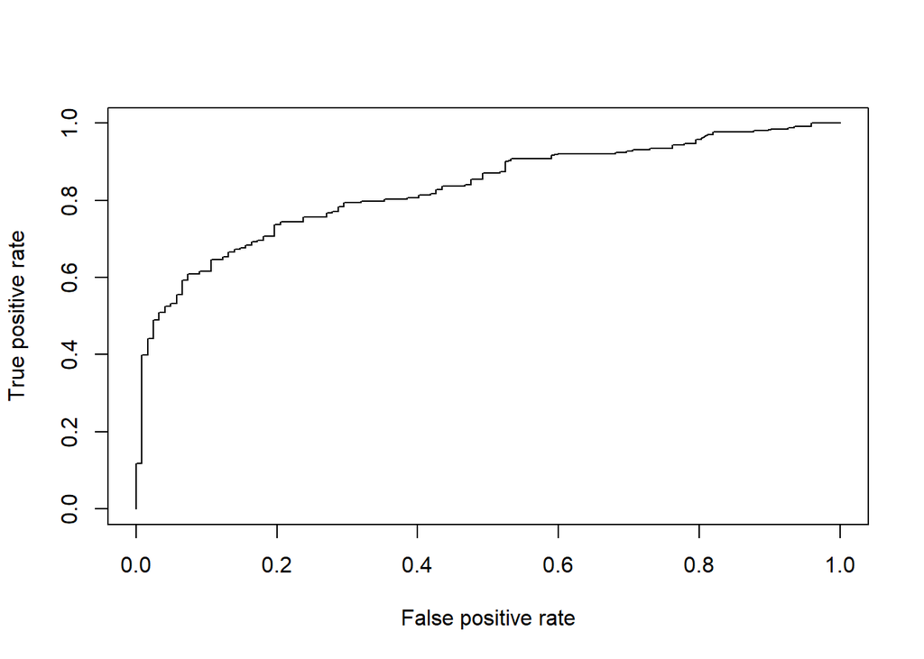

```r
prema$pi_hat <- pi_hat
df_roc <- na.omit(data.frame(pi_hat = prema$pi_hat, PREMATURE = prema$PREMATURE))
pred <- prediction(df_roc$pi_hat, df_roc$PREMATURE)
perf <- performance(pred, "tpr", "fpr")
plot(perf)
```

```r
AUC <- performance(pred, "auc")
attr(AUC, "y.values")[[1]]
```

```
## [1] 0.8300037
```

## Conclusion

Ce modèle de régression logistique met en évidence des facteurs de risque et des facteurs protecteurs cohérents avec la littérature clinique sur l’accouchement prématuré (état du col, antécédents obstétricaux, diabète). Sa capacité prédictive, évaluée par la matrice de confusion et la courbe ROC, montre une bonne sensibilité, avec une marge de progression sur la spécificité — une piste d’amélioration possible serait l’ajustement du seuil de décision ou l’exploration de modèles alternatifs.